# Detecção de Fraudes no Tráfego de Cliques em Propagandas de Aplicações Mobile

Paulo Henrique Piai

22 de dezembro de 2020

## 1 - Definindo o problema de negócio:

#### Prever se o usuário fará o download de um aplicativo ou não após clicar em um anúncio, de modo a prever a ocorrência de fraudes, com base em cliques que não fizeram o download.

## 2 - Coleta e visualização dos dados:

Configurando o diretório de trabalho:

```r
setwd("C:/Projetos_DataScience/Projeto1-Deteccao-Fraudes-Cliques-Propaganda-AppMobile")
```

Verificar o diretório:

```r
getwd()
```

```
## [1] "C:/Projetos_DataScience/Projeto1-Deteccao-Fraudes-Cliques-Propaganda-AppMobile"
```

#### Link para download do dataset:

[Download do dataset](https://www.kaggle.com/c/talkingdata-adtracking-fraud-detection/data)

Carregando os pacotes:

```r
library(data.table)
library(ggplot2)
library(corrplot)
library(dplyr)
library(lubridate)
library(gridExtra)
library(caTools)
library(caret)
library(ROSE)
library(rpart)
library(randomForest)
library(C50)
library(e1071)
library(knitr)
library(rmarkdown)
```

Carregando os dados:

```r
dados <- fread("train_sample.csv", stringsAsFactors = F, sep = ",", header =T)
```

Verificando se há valores missing:

```r
sum(is.na(dados))
```

```
## [1] 0
```

**Não há valores nulos**

Visualizando os dados:

```r
kable(head(dados, 10))
```

| ip | app | device | os | channel | click_time | attributed_time | is_attributed |
| --- | --- | --- | --- | --- | --- | --- | --- |
| 87540 | 12 | 1 | 13 | 497 | 2017-11-07 09:30:38 |  | 0 |
| 105560 | 25 | 1 | 17 | 259 | 2017-11-07 13:40:27 |  | 0 |
| 101424 | 12 | 1 | 19 | 212 | 2017-11-07 18:05:24 |  | 0 |
| 94584 | 13 | 1 | 13 | 477 | 2017-11-07 04:58:08 |  | 0 |
| 68413 | 12 | 1 | 1 | 178 | 2017-11-09 09:00:09 |  | 0 |
| 93663 | 3 | 1 | 17 | 115 | 2017-11-09 01:22:13 |  | 0 |
| 17059 | 1 | 1 | 17 | 135 | 2017-11-09 01:17:58 |  | 0 |
| 121505 | 9 | 1 | 25 | 442 | 2017-11-07 10:01:53 |  | 0 |
| 192967 | 2 | 2 | 22 | 364 | 2017-11-08 09:35:17 |  | 0 |
| 143636 | 3 | 1 | 19 | 135 | 2017-11-08 12:35:26 |  | 0 |

```r
str(dados)
```

```
## Classes 'data.table' and 'data.frame':   100000 obs. of  8 variables:
##  $ ip             : int  87540 105560 101424 94584 68413 93663 17059 121505 192967 143636 ...
##  $ app            : int  12 25 12 13 12 3 1 9 2 3 ...
##  $ device         : int  1 1 1 1 1 1 1 1 2 1 ...
##  $ os             : int  13 17 19 13 1 17 17 25 22 19 ...
##  $ channel        : int  497 259 212 477 178 115 135 442 364 135 ...
##  $ click_time     : chr  "2017-11-07 09:30:38" "2017-11-07 13:40:27" "2017-11-07 18:05:24" "2017-11-07 04:58:08" ...
##  $ attributed_time: chr  "" "" "" "" ...
##  $ is_attributed  : int  0 0 0 0 0 0 0 0 0 0 ...
##  - attr(*, ".internal.selfref")=<externalptr>
```

#### Dicionário dos dados:

- **ip**: ip address of click.
- **app**: app id for marketing.
- **device**: device type id of user mobile phone (e.g., iphone 6 plus, iphone 7, huawei mate 7, etc.)
- **os**: os version id of user mobile phone
- **channel**: channel id of mobile ad publisher
- **click_time**: timestamp of click (UTC)
- **attributed_time**: if user download the app for after clicking an ad, this is the time of the app download
- **is_attributed**: the target that is to be predicted, indicating the app was downloaded  
  **Note that ip, app, device, os, and channel are encoded.**

## 3 - Pré processamento dos dados:

Modificando as variaveis de tempo para o formato correto:

```r
dados$click_time = ymd_hms(dados$click_time)
dados$attributed_time = ymd_hms(dados$attributed_time)
```

Modificando a variável is_attributed para fator, necessário para criar o modelo de classificação:

```r
dados$is_attributed <- as.factor(dados$is_attributed)
```

Visualizando o novo formato das variáveis:

```r
str(dados)
```

```
## Classes 'data.table' and 'data.frame':   100000 obs. of  8 variables:
##  $ ip             : int  87540 105560 101424 94584 68413 93663 17059 121505 192967 143636 ...
##  $ app            : int  12 25 12 13 12 3 1 9 2 3 ...
##  $ device         : int  1 1 1 1 1 1 1 1 2 1 ...
##  $ os             : int  13 17 19 13 1 17 17 25 22 19 ...
##  $ channel        : int  497 259 212 477 178 115 135 442 364 135 ...
##  $ click_time     : POSIXct, format: "2017-11-07 09:30:38" "2017-11-07 13:40:27" ...
##  $ attributed_time: POSIXct, format: NA NA ...
##  $ is_attributed  : Factor w/ 2 levels "0","1": 1 1 1 1 1 1 1 1 1 1 ...
##  - attr(*, ".internal.selfref")=<externalptr>
```

Verificando se há valores missing após a transformação dos dados:

```r
sum(is.na(dados))
```

```
## [1] 99773
```

Retirando a coluna attributed_time do dataset por ter muitos valores NA:

```r
dados$attributed_time <- NULL
```

## 4 - Análise exploratória:

#### Verificando a quantidade de valores unicos:

```r
kable(sapply(dados, function(x) length(unique(x))) %>%
  sort(decreasing = TRUE))
```

|  | x |
| --- | --- |
| click_time | 80350 |
| ip | 34857 |
| app | 161 |
| channel | 161 |
| os | 130 |
| device | 100 |
| is_attributed | 2 |

#### Verificando a quantidade de cliques do mesmo IP:

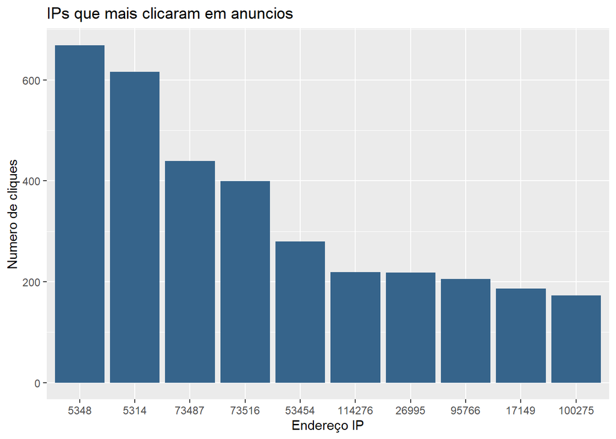

```r
ip <- dados$ip %>%
  table() %>%                   # Verifica a quantidade de valores unicos
  sort(decreasing = TRUE) %>%   # Ordena por ordem decrescente
  head(n = 10L) %>%             # Exibe os 10 IPs que mais fizeram cliques
  as.data.frame()               # Converte para formato data.frame
colnames(ip) <- c('ip_x', 'ip_y')

graph1 <- ggplot(ip, aes(x = ip_x, y = ip_y)) +
  geom_bar(stat="identity", fill = 'steelblue4') +
  ggtitle("IPs que mais clicaram em anuncios")+
  xlab("Endereço IP") +
  ylab("Numero de cliques")
graph1
```

#### Verificando os apps mais acessados:

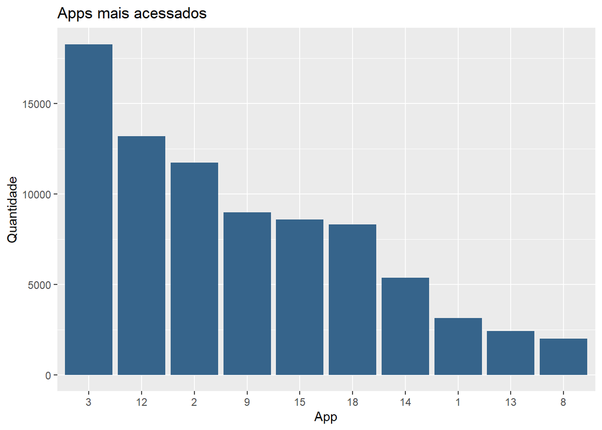

```r
app <- dados$app %>%
  table() %>%                   # Verifica a quantidade de valores unicos
  sort(decreasing = TRUE) %>%   # Ordena por ordem decrescente
  head(n = 10L) %>%             # Exibe os 10 apps mais acessados
  as.data.frame()               # Converte para formato data.frame
colnames(app) <- c('app_x', 'app_y')

graph2 <- ggplot(app, aes(x = app_x, y = app_y)) +
  geom_bar(stat="identity", fill = 'steelblue4') +
  ggtitle("Apps mais acessados")+
  xlab("App") +
  ylab("Quantidade")
graph2
```

#### Verificando os dispositivos mais usados:

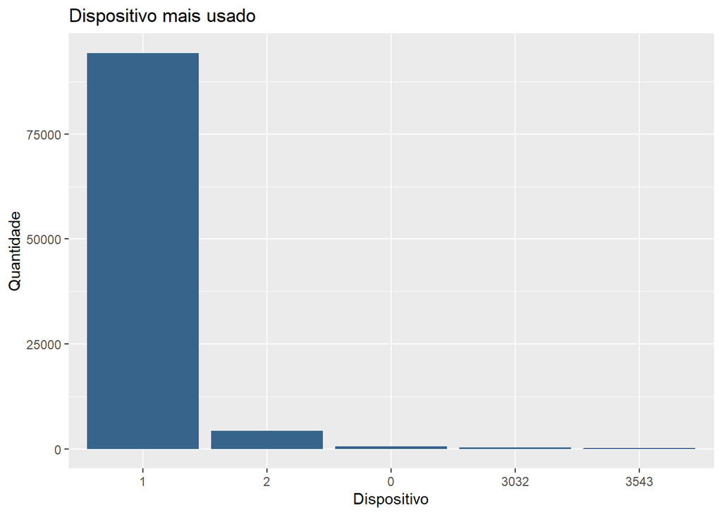

```r
device <- dados$device %>%
  table() %>%                   # Verifica a quantidade de valores unicos
  sort(decreasing = TRUE) %>%   # Ordena por ordem decrescente
  head(n = 5L) %>%              # Exibe os 5 dispositivos mais usados
  as.data.frame()               # Converte para formato data.frame
colnames(device) <- c('device_x', 'device_y')

graph3 <- ggplot(device, aes(x = device_x, y = device_y)) +
  geom_bar(stat="identity", fill = 'steelblue4') +
  ggtitle("Dispositivo mais usado")+
  xlab("Dispositivo") +
  ylab("Quantidade")
graph3
```

#### Verificando o sistema operacional mais usados:

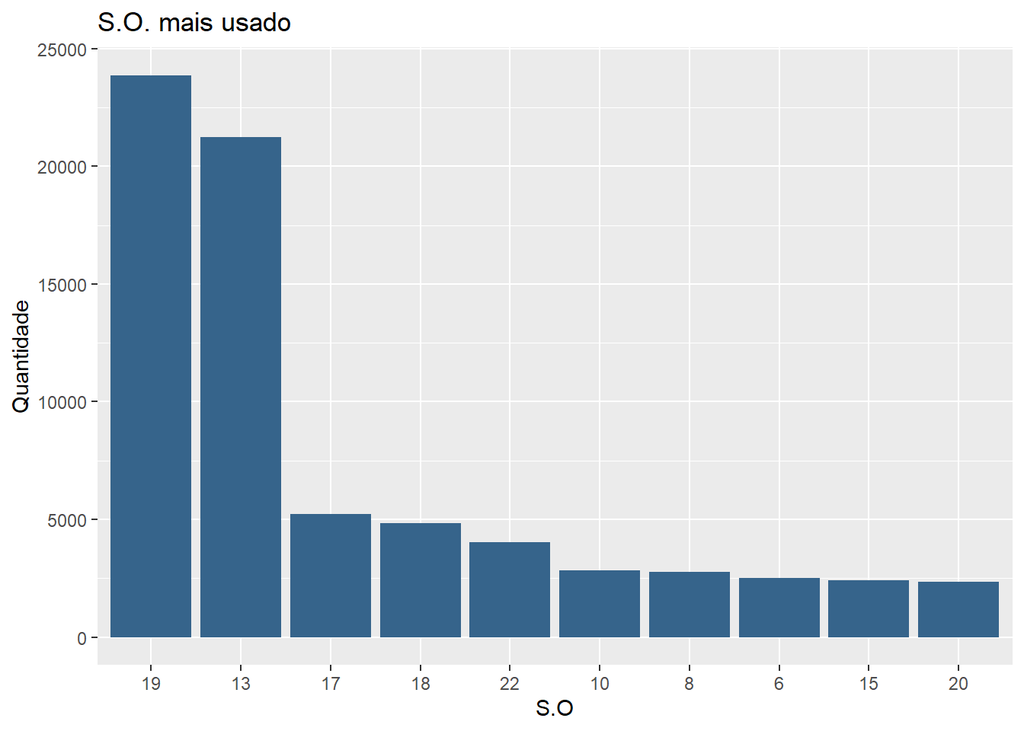

```r
os <- dados$os %>%
  table() %>%                   # Verifica a quantidade de valores unicos
  sort(decreasing = TRUE) %>%   # Ordena por ordem decrescente
  head(n = 10L) %>%             # Exibe os 10 SO mais usados
  as.data.frame()               # Converte para formato data.frame
colnames(os) <- c('os_x', 'os_y')

graph4 <- ggplot(os, aes(x = os_x, y = os_y)) +
  geom_bar(stat="identity", fill = 'steelblue4') +
  ggtitle("S.O. mais usado")+
  xlab("S.O") +
  ylab("Quantidade")
graph4
```

#### Verificando o canal mais usados:

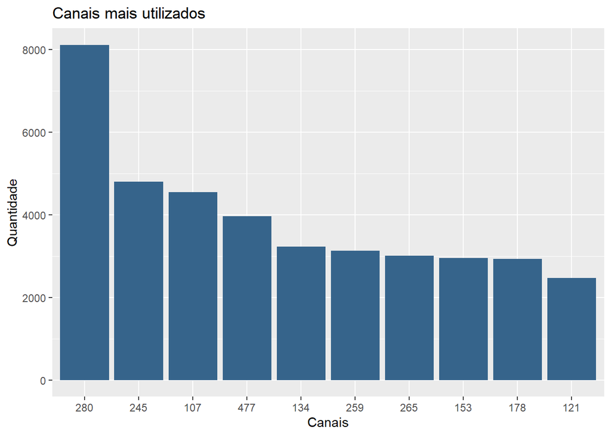

```r
channel <- dados$channel %>%
  table() %>%                   # Verifica a quantidade de valores unicos
  sort(decreasing = TRUE) %>%   # Ordena por ordem decrescente
  head(n = 10L) %>%             # Exibe os 10 canais mais utilizados
  as.data.frame()               # Converte para formato data.frame
colnames(channel) <- c('ch_x', 'ch_y')

graph5 <- ggplot(channel, aes(x = ch_x, y = ch_y)) +
  geom_bar(stat="identity", fill = 'steelblue4') +
  ggtitle("Canais mais utilizados")+
  xlab("Canais") +
  ylab("Quantidade")
graph5
```

#### Plotando os gráficos simultaneos:

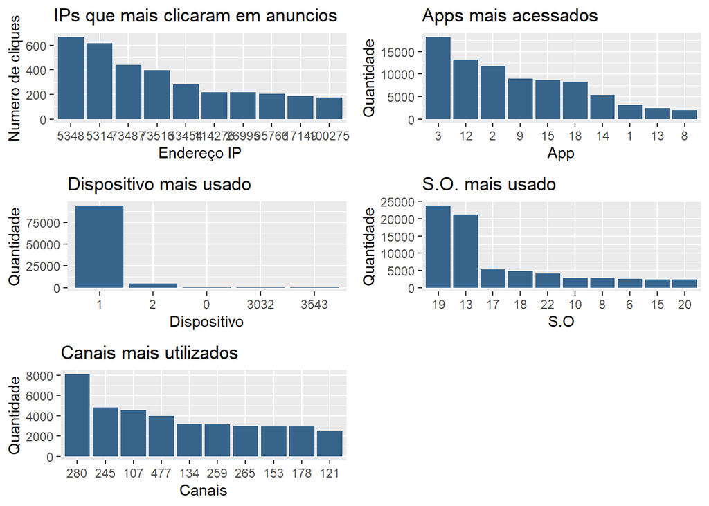

```r
grid.arrange(graph1, graph2, graph3, graph4, graph5)
```

#### Verificando o balanceamento dos dados:

```r
prop.table(table(dados$is_attributed))*100
```

```
##
##      0      1
## 99.773  0.227
```

Verificando o resultado graficamente:

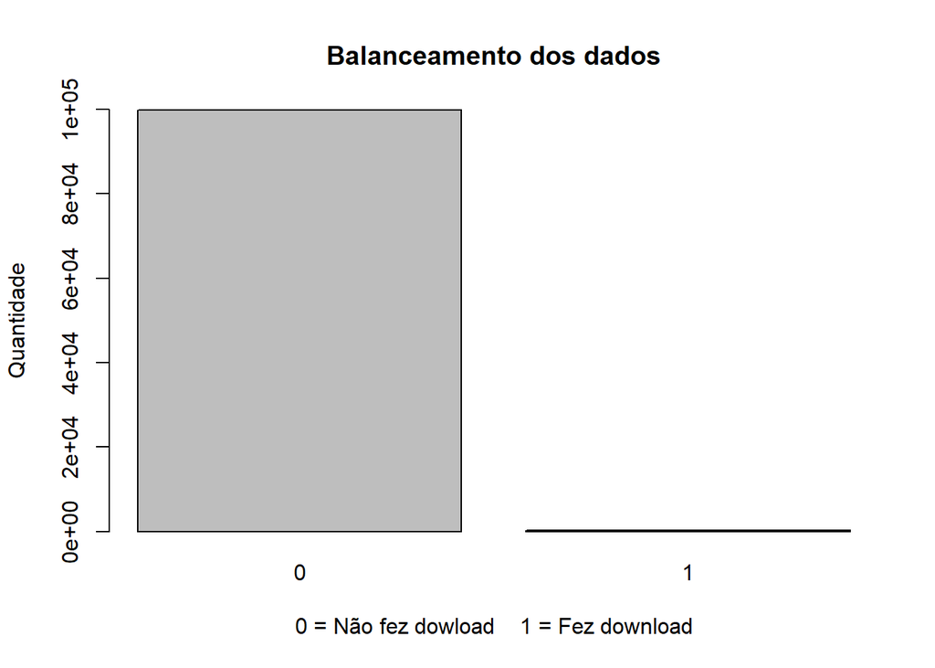

```r
barplot(table(dados$is_attributed),
        main = "Balanceamento dos dados",
        xlab = '0 = Não fez dowload    1 = Fez download',
        ylab = 'Quantidade',
        ylim = c (0,100e3))
```

##### **Mais de 99% dos dados é referente a IPs que não fizeram o download do app. Ou seja, a classe está completamente desbalanceada.**

#### Verificando a correlação entre os dados:

Transformando as variáveis para numeric:

```r
dados_cor <- dados %>%
  mutate_if(is.factor, as.integer)
```

Plotando a matriz de correlação:

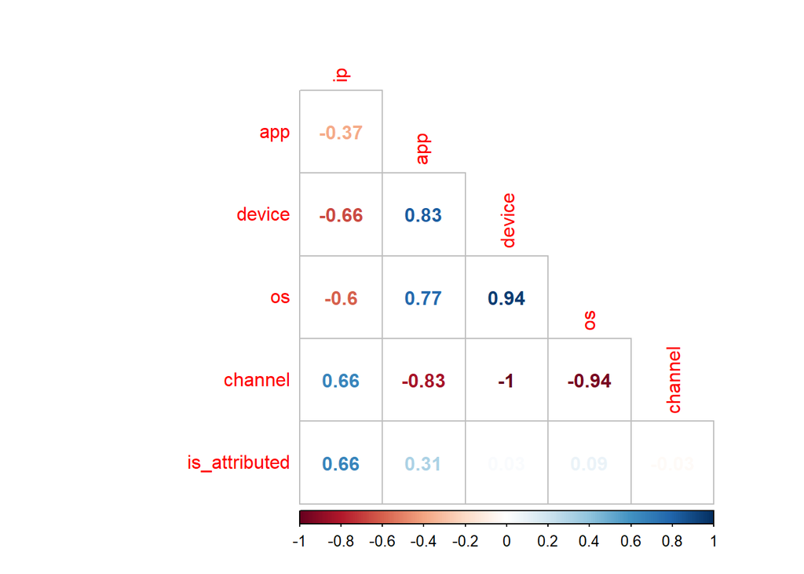

```r
cor(dados_cor[, -c('click_time')]) %>%
  cor(method = 'spearman') %>%
  corrplot(method = 'number', diag = FALSE, type = 'lower')
```

##### **O IP apresenta uma correlação positiva de 66% com a variável target.**

#### Verificando o padrão cliques e download por horario:

```r
dados_time <- dados[, c('click_time','is_attributed')]
str(dados_time)
```

```
## Classes 'data.table' and 'data.frame':   100000 obs. of  2 variables:
##  $ click_time   : POSIXct, format: "2017-11-07 09:30:38" "2017-11-07 13:40:27" ...
##  $ is_attributed: Factor w/ 2 levels "0","1": 1 1 1 1 1 1 1 1 1 1 ...
##  - attr(*, ".internal.selfref")=<externalptr>
```

```r
kable(head(dados_time))
```

| click_time | is_attributed |
| --- | --- |
| 2017-11-07 09:30:38 | 0 |
| 2017-11-07 13:40:27 | 0 |
| 2017-11-07 18:05:24 | 0 |
| 2017-11-07 04:58:08 | 0 |
| 2017-11-09 09:00:09 | 0 |
| 2017-11-09 01:22:13 | 0 |

Verificando o numero de cliques para cada hora:

```r
hora <- hour(dados_time$click_time)

numero_cliques <- dados_time[, .N, by = hora]
numero_cliques
```

```
##     hora    N
##  1:    9 4867
##  2:   13 5619
##  3:   18 1183
##  4:    4 6039
##  5:    1 5103
##  6:   10 5511
##  7:   12 5326
##  8:    8 4576
##  9:    5 5400
## 10:   14 5561
## 11:    0 5654
## 12:   23 3870
## 13:    7 5089
## 14:    3 5264
## 15:   20  699
## 16:   17 2176
## 17:    2 5137
## 18:   16 3812
## 19:    6 5079
## 20:   11 5342
## 21:   15 4957
## 22:   19  870
## 23:   22 2002
## 24:   21  864
##     hora    N
```

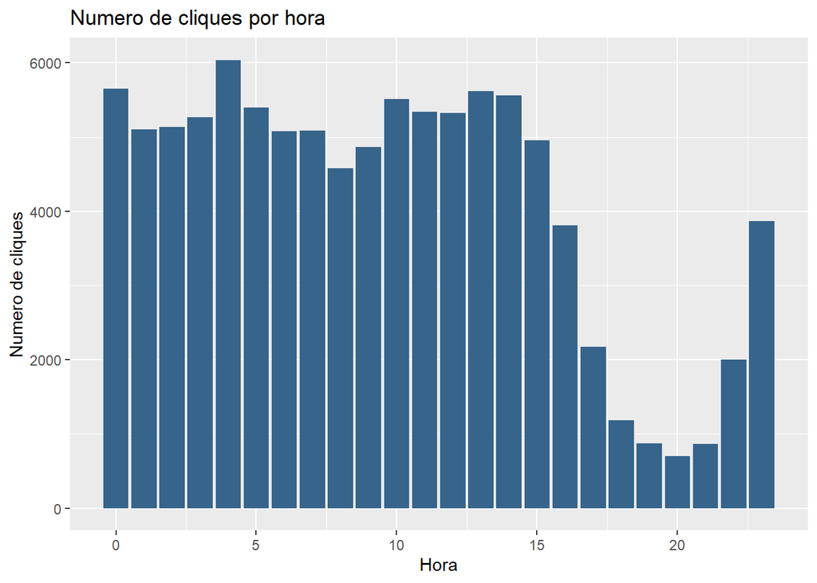

```r
# Plotando gráfico de numero de cliques por hora:
graph6 <- ggplot(numero_cliques, aes(x = hora, y = N)) +
  geom_bar(stat="identity", fill="steelblue4")+
  ggtitle("Numero de cliques por hora")+
  xlab("Hora") +
  ylab("Numero de cliques")
graph6
```

Verificando o numero de download para cada hora:

```r
dados_time$hora <- hour(dados_time$click_time)
numero_download <- dados_time[is_attributed == 1, .N,
                              by = c('hora','is_attributed')]
numero_download
```

```
##     hora is_attributed  N
##  1:    2             1 10
##  2:    6             1 12
##  3:    9             1 10
##  4:   10             1 16
##  5:   22             1  3
##  6:   12             1 14
##  7:   18             1  2
##  8:    8             1 13
##  9:    4             1 10
## 10:   20             1  2
## 11:    5             1 15
## 12:    3             1 15
## 13:    7             1 13
## 14:   15             1  9
## 15:   14             1 17
## 16:   23             1 13
## 17:    0             1 13
## 18:    1             1 15
## 19:   13             1 10
## 20:   11             1 10
## 21:   17             1  2
## 22:   21             1  3
##     hora is_attributed  N
```

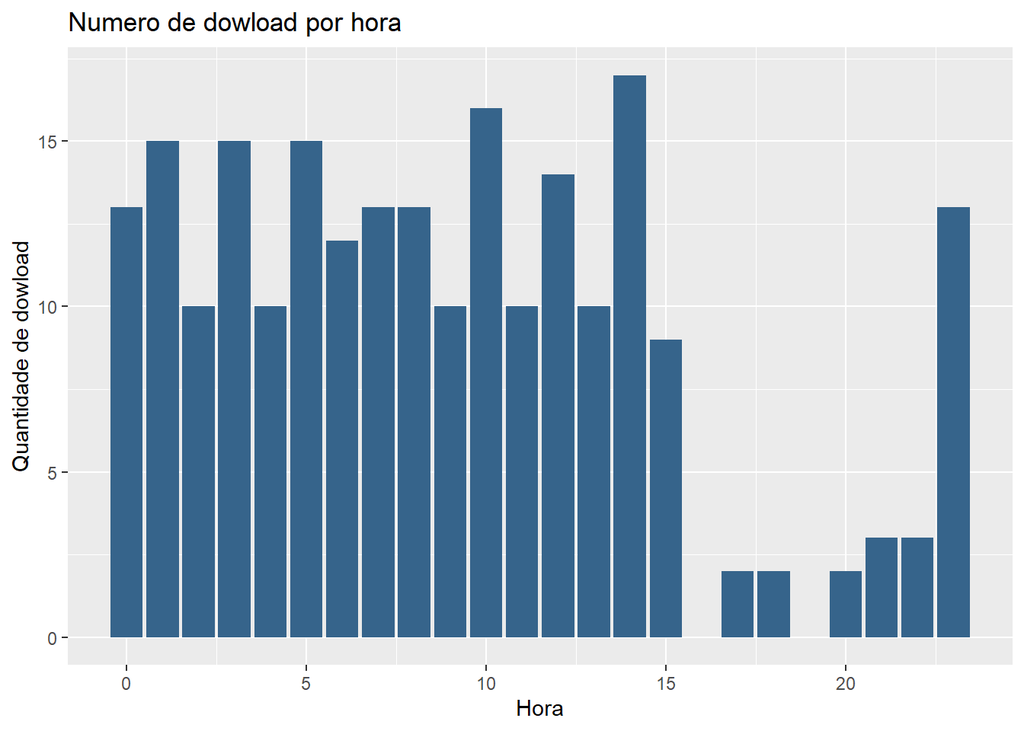

```r
# Plotando gráfico de numero de cliques por hora:
graph7 <- ggplot(numero_download, aes(x = hora, y = N)) +
  geom_bar(stat="identity", fill="steelblue4")+
  ggtitle("Numero de dowload por hora")+
  xlab("Hora") +
  ylab("Quantidade de dowload")
graph7
```

Plotando os dois gráficos simultaneos:

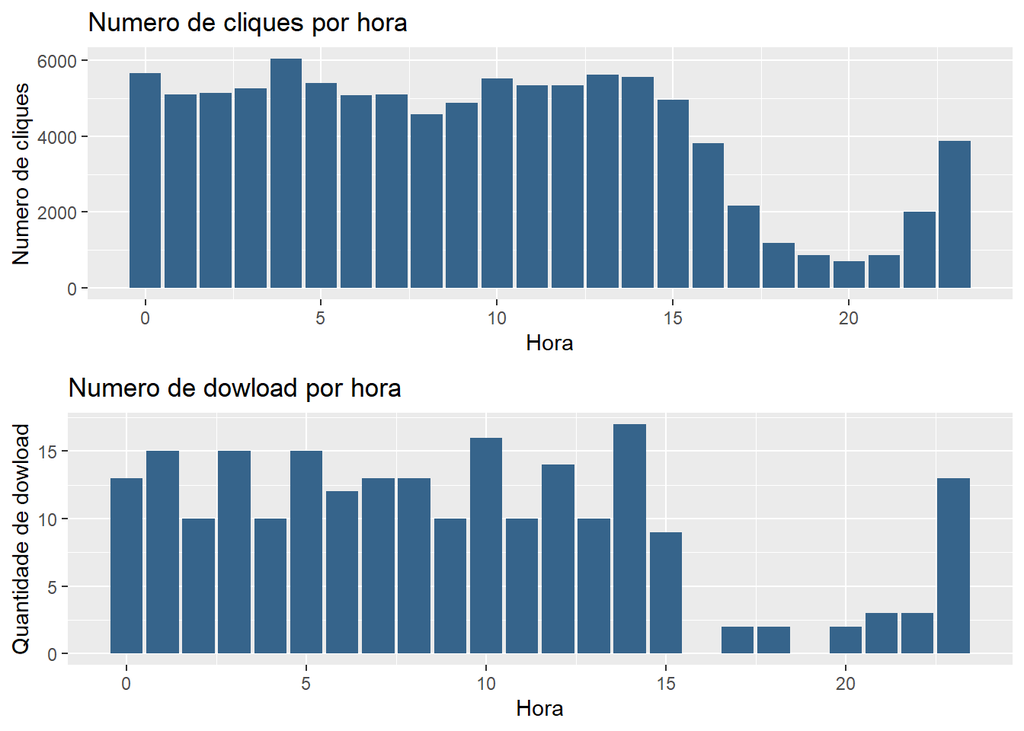

```r
grid.arrange(graph6, graph7)
```

#### **O menor numero de cliques ocorre proximo das 20hrs. O numero de downloads segue o mesmo padrão.**

## 5 - Construção do modelo preditivo:

Dividindo os dados em treino (70%) e teste (30%)

```r
set.seed(0)
amostra <- sample.split(dados$is_attributed, SplitRatio = 0.7)
dados_treino <- subset(dados, amostra == TRUE)
dados_teste <- subset(dados, amostra == FALSE)
```

Visualisando o formato dos dodos:

```r
str(dados_treino)
```

```
## Classes 'data.table' and 'data.frame':   70000 obs. of  7 variables:
##  $ ip           : int  105560 101424 94584 93663 192967 143636 73839 34812 114809 114220 ...
##  $ app          : int  25 12 13 3 2 3 3 3 3 6 ...
##  $ device       : int  1 1 1 1 2 1 1 1 1 1 ...
##  $ os           : int  17 19 13 17 22 19 22 13 22 20 ...
##  $ channel      : int  259 212 477 115 364 135 489 489 205 125 ...
##  $ click_time   : POSIXct, format: "2017-11-07 13:40:27" "2017-11-07 18:05:24" ...
##  $ is_attributed: Factor w/ 2 levels "0","1": 1 1 1 1 1 1 1 1 1 1 ...
##  - attr(*, ".internal.selfref")=<externalptr>
```

```r
str(dados_teste)
```

```
## Classes 'data.table' and 'data.frame':   30000 obs. of  7 variables:
##  $ ip           : int  87540 68413 17059 121505 72116 106598 72065 28735 66918 139137 ...
##  $ app          : int  12 12 1 9 25 3 20 12 64 12 ...
##  $ device       : int  1 1 1 1 2 1 2 1 1 1 ...
##  $ os           : int  13 1 17 25 19 20 90 19 25 13 ...
##  $ channel      : int  497 178 135 442 259 280 259 265 459 497 ...
##  $ click_time   : POSIXct, format: "2017-11-07 09:30:38" "2017-11-09 09:00:09" ...
##  $ is_attributed: Factor w/ 2 levels "0","1": 1 1 1 1 1 1 1 1 1 1 ...
##  - attr(*, ".internal.selfref")=<externalptr>
```

Verificando a proporção dos dados de treino e teste:

```r
prop.table(table(dados_treino$is_attributed))*100
```

```
##
##          0          1
## 99.7728571  0.2271429
```

```r
prop.table(table(dados_teste$is_attributed))*100
```

```
##
##          0          1
## 99.7733333  0.2266667
```

Criando o modelo sem balanceamento dos dados:

```r
modelo1 <- rpart (data = dados_treino,
                is_attributed ~ .,
                control = rpart.control(cp = .0005))
print(modelo1)
```

```
## n= 70000
##
## node), split, n, loss, yval, (yprob)
##       * denotes terminal node
##
##   1) root 70000 159 0 (0.9977285714 0.0022714286)
##     2) device>=0.5 69621 123 0 (0.9982332917 0.0017667083)
##       4) app< 28.5 67712  59 0 (0.9991286626 0.0008713374)
##         8) device< 3 67363  42 0 (0.9993765123 0.0006234877)
##          16) channel>=114 61678  20 0 (0.9996757353 0.0003242647) *
##          17) channel< 114 5685  22 0 (0.9961301671 0.0038698329)
##            34) channel< 112 5488   1 0 (0.9998177843 0.0001822157) *
##            35) channel>=112 197  21 0 (0.8934010152 0.1065989848)
##              70) ip< 163195 147   3 0 (0.9795918367 0.0204081633) *
##              71) ip>=163195 50  18 0 (0.6400000000 0.3600000000)
##               142) os< 26 29   4 0 (0.8620689655 0.1379310345) *
##               143) os>=26 21   7 1 (0.3333333333 0.6666666667) *
##         9) device>=3 349  17 0 (0.9512893983 0.0487106017) *
##       5) app>=28.5 1909  64 0 (0.9664745940 0.0335254060)
##        10) channel>=278 1505   9 0 (0.9940199336 0.0059800664) *
##        11) channel< 278 404  55 0 (0.8638613861 0.1361386139)
##          22) ip< 178502.5 341  26 0 (0.9237536657 0.0762463343)
##            44) channel< 271 334  21 0 (0.9371257485 0.0628742515) *
##            45) channel>=271 7   2 1 (0.2857142857 0.7142857143) *
##          23) ip>=178502.5 63  29 0 (0.5396825397 0.4603174603)
##            46) channel< 233.5 55  21 0 (0.6181818182 0.3818181818)
##              92) ip< 230074 29   6 0 (0.7931034483 0.2068965517) *
##              93) ip>=230074 26  11 1 (0.4230769231 0.5769230769)
##               186) os>=19.5 7   1 0 (0.8571428571 0.1428571429) *
##               187) os< 19.5 19   5 1 (0.2631578947 0.7368421053) *
##            47) channel>=233.5 8   0 1 (0.0000000000 1.0000000000) *
##     3) device< 0.5 379  36 0 (0.9050131926 0.0949868074) *
```

Previsão:

```r
previsao1 <- predict(modelo1, dados_teste, type = 'class')
```

Criando uma confusion matrix:

```r
caret::confusionMatrix(previsao1, dados_teste$is_attributed,
                       positive = '1')
```

```
## Confusion Matrix and Statistics
##
##           Reference
## Prediction     0     1
##          0 29923    54
##          1     9    14
##
##                Accuracy : 0.9979
##                  95% CI : (0.9973, 0.9984)
##     No Information Rate : 0.9977
##     P-Value [Acc > NIR] : 0.2973
##
##                   Kappa : 0.3069
##
##  Mcnemar's Test P-Value : 2.965e-08
##
##             Sensitivity : 0.2058824
##             Specificity : 0.9996993
##          Pos Pred Value : 0.6086957
##          Neg Pred Value : 0.9981986
##              Prevalence : 0.0022667
##          Detection Rate : 0.0004667
##    Detection Prevalence : 0.0007667
##       Balanced Accuracy : 0.6027908
##
##        'Positive' Class : 1
##
```

Criando a Curva ROC para encontrar a métrica AUC:

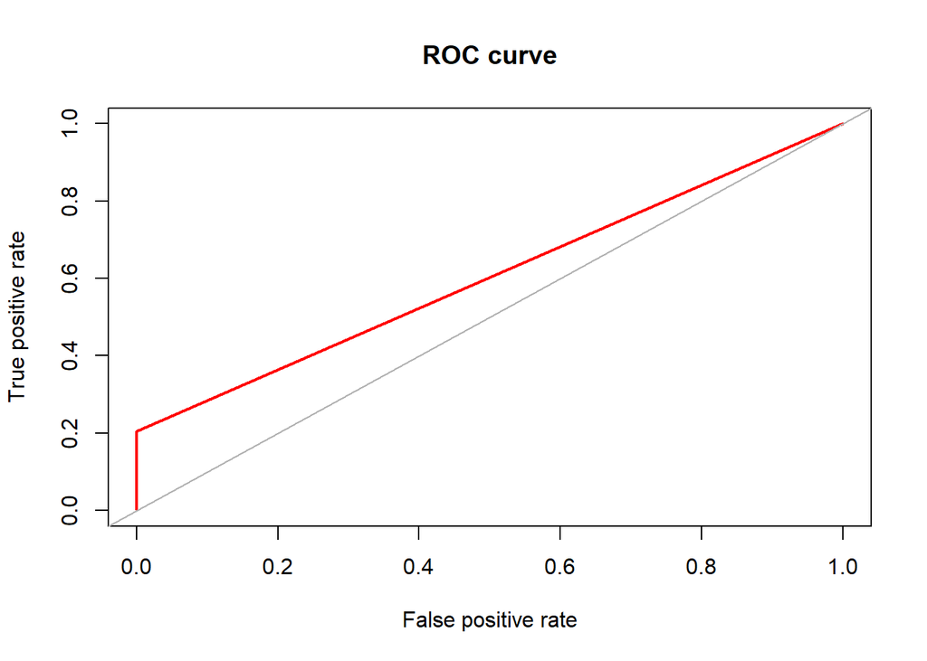

```
## Area under the curve (AUC): 0.603
```

```r
roc.curve(dados_teste$is_attributed, previsao1, plotit = T, col = "red")
```

#### **Acurácia** = 0.9979

#### **Score AUC** = 0.603

#### **Se analisarmos apenas a acuracia do modelo, estaria excelente (99%).Mais analisando a curva AUC, temos o valor de 0.603. Podemos melhorar o modelo balanceando os dados.**

## 6 - Balanceando os dados para criação do modelo:

#### Aplicando ROSE em dados de treino e teste e checando a proporção de classes.

Alterando o tipo da variavél click_time para numérica:

```r
dados_treino$click_time <- as.numeric(dados_treino$click_time)
dados_teste$click_time <- as.numeric(dados_teste$click_time)
```

Verificando os dados:

```r
str(dados_treino)
```

```
## Classes 'data.table' and 'data.frame':   70000 obs. of  7 variables:
##  $ ip           : int  105560 101424 94584 93663 192967 143636 73839 34812 114809 114220 ...
##  $ app          : int  25 12 13 3 2 3 3 3 3 6 ...
##  $ device       : int  1 1 1 1 2 1 1 1 1 1 ...
##  $ os           : int  17 19 13 17 22 19 22 13 22 20 ...
##  $ channel      : int  259 212 477 115 364 135 489 489 205 125 ...
##  $ click_time   : num  1.51e+09 1.51e+09 1.51e+09 1.51e+09 1.51e+09 ...
##  $ is_attributed: Factor w/ 2 levels "0","1": 1 1 1 1 1 1 1 1 1 1 ...
##  - attr(*, ".internal.selfref")=<externalptr>
```

```r
str(dados_teste)
```

```
## Classes 'data.table' and 'data.frame':   30000 obs. of  7 variables:
##  $ ip           : int  87540 68413 17059 121505 72116 106598 72065 28735 66918 139137 ...
##  $ app          : int  12 12 1 9 25 3 20 12 64 12 ...
##  $ device       : int  1 1 1 1 2 1 2 1 1 1 ...
##  $ os           : int  13 1 17 25 19 20 90 19 25 13 ...
##  $ channel      : int  497 178 135 442 259 280 259 265 459 497 ...
##  $ click_time   : num  1.51e+09 1.51e+09 1.51e+09 1.51e+09 1.51e+09 ...
##  $ is_attributed: Factor w/ 2 levels "0","1": 1 1 1 1 1 1 1 1 1 1 ...
##  - attr(*, ".internal.selfref")=<externalptr>
```

Balanceando os dados de treino:

```r
rose_treino <- ROSE(is_attributed ~.,
                    data = dados_treino, seed = 1)$data
prop.table(table(rose_treino$is_attributed))*100
```

```
##
##        0        1
## 49.88429 50.11571
```

**Agora os dados estão com uma proporção de ~50% para as duas classes.**

Balanceando os dados de teste:

```r
rose_teste <- ROSE(is_attributed ~.,
                    data = dados_teste, seed = 1)$data
prop.table(table(rose_teste$is_attributed))*100
```

```
##
##        0        1
## 50.40333 49.59667
```

**Agora os dados estão com uma proporção de ~50% para as duas classes.**

Criando um novo modelo com os dados balanceados:

```r
modelo2 <- rpart (data = rose_treino,
                  is_attributed ~ .,
                  control = rpart.control(cp = .0005))
```

Previsão:

```r
previsao2 <- predict(modelo2, rose_teste, type = 'class')
```

Criando uma confusion matrix:

```r
caret::confusionMatrix(previsao2, rose_teste$is_attributed,
                       positive = '1')
```

```
## Confusion Matrix and Statistics
##
##           Reference
## Prediction     0     1
##          0 13072  1998
##          1  2049 12881
##
##                Accuracy : 0.8651
##                  95% CI : (0.8612, 0.8689)
##     No Information Rate : 0.504
##     P-Value [Acc > NIR] : <2e-16
##
##                   Kappa : 0.7302
##
##  Mcnemar's Test P-Value : 0.4319
##
##             Sensitivity : 0.8657
##             Specificity : 0.8645
##          Pos Pred Value : 0.8628
##          Neg Pred Value : 0.8674
##              Prevalence : 0.4960
##          Detection Rate : 0.4294
##    Detection Prevalence : 0.4977
##       Balanced Accuracy : 0.8651
##
##        'Positive' Class : 1
##
```

Criando a Curva ROC para encontrar a métrica AUC:

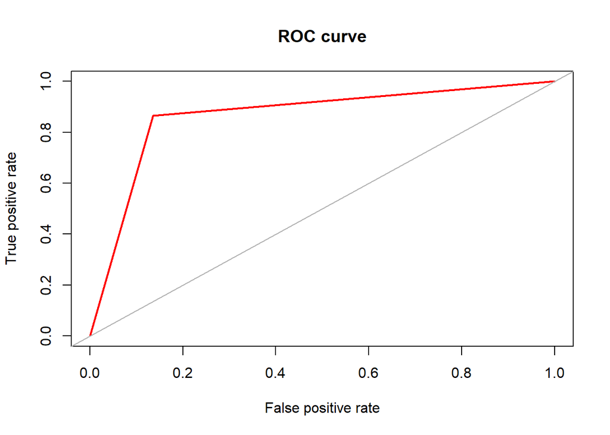

```
## Area under the curve (AUC): 0.865
```

```r
roc.curve(rose_teste$is_attributed, previsao2, plotit = T, col = "red")
```

#### **Acurácia** = 0.8651

#### **Score AUC** = 0.865

#### **Diminuimos a acuracia do modelo, porém, o score AUC aumentou significativamente. Portanto, o modelo2 é melhor que o modelo1, indicando que os dados precisam estar balanceados para uma melhor performance do modelo.**

## 7 - Otimizando o modelo:

### 7.1 - Verificando outros métodos de balanceamento dos dados:

#### 7.1.1 - Over sampling:

Balanceando dos dados de treino:

```r
dados_treino_over <- ovun.sample(is_attributed ~ ., data = dados_treino,
                          method = "over")$data
prop.table(table(dados_treino_over$is_attributed))*100
```

```
##
##        0        1
## 49.98855 50.01145
```

Balanceando os dados de teste:

```r
dados_teste_over <- ovun.sample(is_attributed ~ ., data = dados_teste,
                                method = "over")$data
prop.table(table(dados_teste_over$is_attributed))*100
```

```
##
##        0        1
## 49.96578 50.03422
```

Criando um novo modelo com os dados balanceados:

```r
modelo3 <- rpart (data = dados_treino_over,
                  is_attributed ~ .,
                  control = rpart.control(cp = .0005))
```

Previsão:

```r
previsao3 <- predict(modelo3, dados_teste_over, type = 'class')
```

Criando uma confusion matrix:

```r
caret::confusionMatrix(previsao3, dados_teste_over$is_attributed,
                       positive = '1')
```

```
## Confusion Matrix and Statistics
##
##           Reference
## Prediction     0     1
##          0 29352  3499
##          1   580 26474
##
##                Accuracy : 0.9319
##                  95% CI : (0.9299, 0.9339)
##     No Information Rate : 0.5003
##     P-Value [Acc > NIR] : < 2.2e-16
##
##                   Kappa : 0.8638
##
##  Mcnemar's Test P-Value : < 2.2e-16
##
##             Sensitivity : 0.8833
##             Specificity : 0.9806
##          Pos Pred Value : 0.9786
##          Neg Pred Value : 0.8935
##              Prevalence : 0.5003
##          Detection Rate : 0.4419
##    Detection Prevalence : 0.4516
##       Balanced Accuracy : 0.9319
##
##        'Positive' Class : 1
##
```

Criando a Curva ROC para encontrar a métrica AUC:

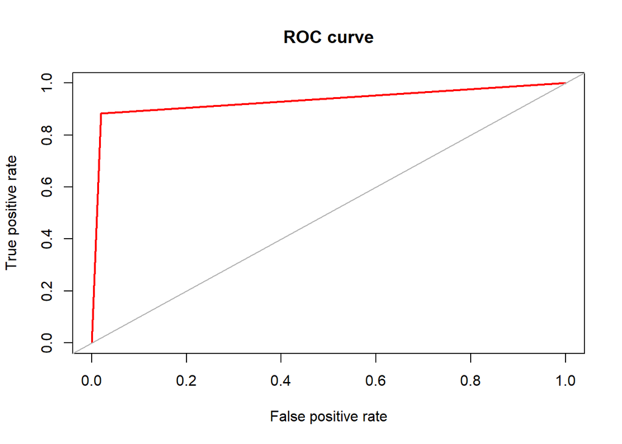

```
## Area under the curve (AUC): 0.932
```

```r
roc.curve(dados_teste_over$is_attributed, previsao3, plotit = T, col = "red")
```

#### **Acurácia** = 0.9319

#### **Score AUC** = 0.932

#### 7.1.2 - Under sampling:

Balanceando dos dados de treino:

```r
dados_treino_under <- ovun.sample(is_attributed ~ ., data = dados_treino,
                                 method = "under")$data
prop.table(table(dados_treino_under$is_attributed))*100
```

```
##
##        0        1
## 50.77399 49.22601
```

Balanceando os dados de teste:

```r
dados_teste_under <- ovun.sample(is_attributed ~ ., data = dados_teste,
                                method = "under")$data
prop.table(table(dados_teste_under$is_attributed))*100
```

```
##
##        0        1
## 49.62963 50.37037
```

Criando um novo modelo com os dados balanceados:

```r
modelo4 <- rpart (data = dados_treino_under,
                  is_attributed ~ .,
                  control = rpart.control(cp = .0005))
```

Previsão:

```r
previsao4 <- predict(modelo4, dados_teste_under, type = 'class')
```

Criando uma confusion matrix:

```r
caret::confusionMatrix(previsao4, dados_teste_under$is_attributed,
                       positive = '1')
```

```
## Confusion Matrix and Statistics
##
##           Reference
## Prediction  0  1
##          0 63  8
##          1  4 60
##
##                Accuracy : 0.9111
##                  95% CI : (0.8499, 0.9532)
##     No Information Rate : 0.5037
##     P-Value [Acc > NIR] : <2e-16
##
##                   Kappa : 0.8223
##
##  Mcnemar's Test P-Value : 0.3865
##
##             Sensitivity : 0.8824
##             Specificity : 0.9403
##          Pos Pred Value : 0.9375
##          Neg Pred Value : 0.8873
##              Prevalence : 0.5037
##          Detection Rate : 0.4444
##    Detection Prevalence : 0.4741
##       Balanced Accuracy : 0.9113
##
##        'Positive' Class : 1
##
```

Criando a Curva ROC para encontrar a métrica AUC:

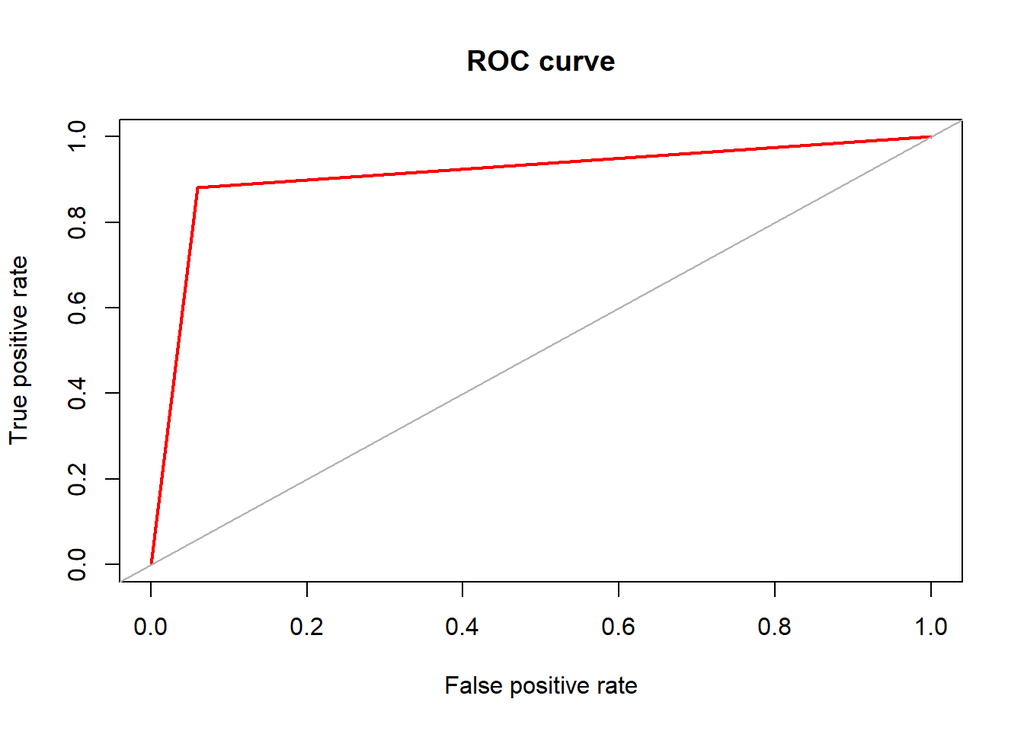

```
## Area under the curve (AUC): 0.911
```

```r
roc.curve(dados_teste_under$is_attributed, previsao4, plotit = T, col = "red")
```

#### **Acurácia** = 0.9111

#### **Score AUC** = 0.911

#### 7.1.3 - Both sampling:

Balanceando dos dados de treino:

```r
dados_treino_both <- ovun.sample(is_attributed ~ ., data = dados_treino,
                                  method = "both")$data
prop.table(table(dados_treino_both$is_attributed))*100
```

```
##
##        0        1
## 50.23429 49.76571
```

Balanceando os dados de teste:

```r
dados_teste_both <- ovun.sample(is_attributed ~ ., data = dados_teste,
                                 method = "both")$data
prop.table(table(dados_teste_both$is_attributed))*100
```

```
##
##     0     1
## 49.41 50.59
```

Criando um novo modelo com os dados balanceados:

```r
modelo5 <- rpart (data = dados_treino_both,
                  is_attributed ~ .,
                  control = rpart.control(cp = .0005))
```

Previsão:

```r
previsao5 <- predict(modelo5, dados_teste_both, type = 'class')
```

Criando uma confusion matrix:

```r
caret::confusionMatrix(previsao5, dados_teste_both$is_attributed,
                       positive = '1')
```

```
## Confusion Matrix and Statistics
##
##           Reference
## Prediction     0     1
##          0 14548  1825
##          1   275 13352
##
##                Accuracy : 0.93
##                  95% CI : (0.9271, 0.9329)
##     No Information Rate : 0.5059
##     P-Value [Acc > NIR] : < 2.2e-16
##
##                   Kappa : 0.8602
##
##  Mcnemar's Test P-Value : < 2.2e-16
##
##             Sensitivity : 0.8798
##             Specificity : 0.9814
##          Pos Pred Value : 0.9798
##          Neg Pred Value : 0.8885
##              Prevalence : 0.5059
##          Detection Rate : 0.4451
##    Detection Prevalence : 0.4542
##       Balanced Accuracy : 0.9306
##
##        'Positive' Class : 1
##
```

Criando a Curva ROC para encontrar a métrica AUC:

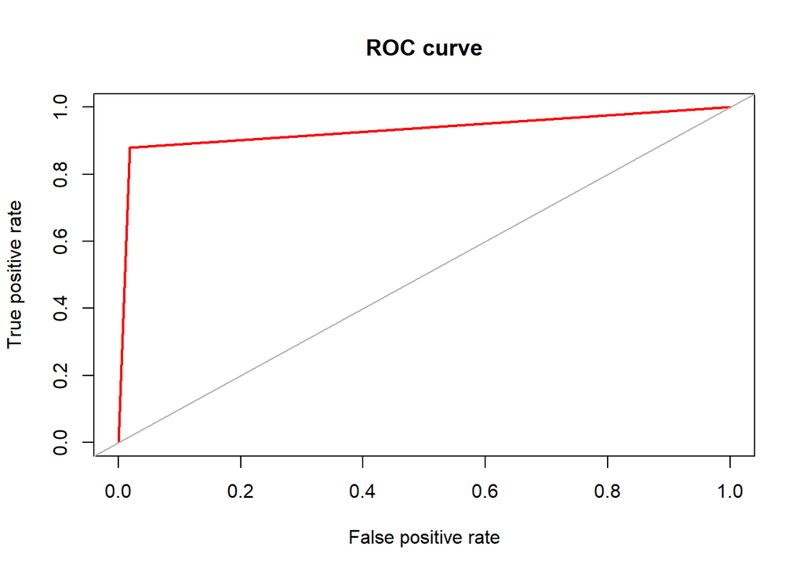

```
## Area under the curve (AUC): 0.931
```

```r
roc.curve(dados_teste_both$is_attributed, previsao5, plotit = T, col = "red")
```

#### **Score AUC** = 0.931

### **Score dos 4 modelos de balanceamento:**

#### **ROSE =**

```
Acurácia = 0.8651
Score AUC = 0.865
```

#### **OVER SAMPLING =**

```
Acurácia = 0.9319
Score AUC = 0.932
```

#### **UNDER SAMPLING =**

```
Acurácia = 0.9111
Score AUC = 0.911
```

#### **BOTH SAMPLING =**

```
Acurácia = 0.93
Score AUC = 0.931
```

#### **O balanceamento utilizando over sampling e both sampling apresentaram um melhor resultado, com valores proximos um do outro, porém, o balanceamento, utilizando over sampling não diminui tanto o tamanho do dataset em relação aos demais métodos de balanceamento, por isso, será utilizado o modelo de over sampling.**

### 7.2 - Testando outros algoritmos de classificação:

```r
str(dados_teste_over)
```

```
## 'data.frame':    59905 obs. of  7 variables:
##  $ ip           : int  87540 68413 17059 121505 72116 106598 72065 28735 66918 139137 ...
##  $ app          : int  12 12 1 9 25 3 20 12 64 12 ...
##  $ device       : int  1 1 1 1 2 1 2 1 1 1 ...
##  $ os           : int  13 1 17 25 19 20 90 19 25 13 ...
##  $ channel      : int  497 178 135 442 259 280 259 265 459 497 ...
##  $ click_time   : num  1.51e+09 1.51e+09 1.51e+09 1.51e+09 1.51e+09 ...
##  $ is_attributed: Factor w/ 2 levels "0","1": 1 1 1 1 1 1 1 1 1 1 ...
```

```r
str(dados_treino_over)
```

```
## 'data.frame':    139714 obs. of  7 variables:
##  $ ip           : int  105560 101424 94584 93663 192967 143636 73839 34812 114809 114220 ...
##  $ app          : int  25 12 13 3 2 3 3 3 3 6 ...
##  $ device       : int  1 1 1 1 2 1 1 1 1 1 ...
##  $ os           : int  17 19 13 17 22 19 22 13 22 20 ...
##  $ channel      : int  259 212 477 115 364 135 489 489 205 125 ...
##  $ click_time   : num  1.51e+09 1.51e+09 1.51e+09 1.51e+09 1.51e+09 ...
##  $ is_attributed: Factor w/ 2 levels "0","1": 1 1 1 1 1 1 1 1 1 1 ...
```

#### 7.2.1 - Utilizando o random forest:

Criando o modelo:

```r
modelo6 <- randomForest(data = dados_treino_over,
                  is_attributed ~ .,
                  ntree = 100,
                  nodesize = 10)
print(modelo6)
```

```
##
## Call:
##  randomForest(formula = is_attributed ~ ., data = dados_treino_over,      ntree = 100, nodesize = 10)
##                Type of random forest: classification
##                      Number of trees: 100
## No. of variables tried at each split: 2
##
##         OOB estimate of  error rate: 0.07%
## Confusion matrix:
##       0     1 class.error
## 0 69743    98 0.001403187
## 1     0 69873 0.000000000
```

Previsão:

```r
previsao6 <- predict(modelo6, dados_teste_over, type = 'class')
```

Criando uma confusion matrix:

```r
caret::confusionMatrix(previsao6, dados_teste_over$is_attributed,
                       positive = '1')
```

```
## Confusion Matrix and Statistics
##
##           Reference
## Prediction     0     1
##          0 29890 19285
##          1    42 10688
##
##                Accuracy : 0.6774
##                  95% CI : (0.6736, 0.6811)
##     No Information Rate : 0.5003
##     P-Value [Acc > NIR] : < 2.2e-16
##
##                   Kappa : 0.355
##
##  Mcnemar's Test P-Value : < 2.2e-16
##
##             Sensitivity : 0.3566
##             Specificity : 0.9986
##          Pos Pred Value : 0.9961
##          Neg Pred Value : 0.6078
##              Prevalence : 0.5003
##          Detection Rate : 0.1784
##    Detection Prevalence : 0.1791
##       Balanced Accuracy : 0.6776
##
##        'Positive' Class : 1
##
```

Criando a Curva ROC para encontrar a métrica AUC:

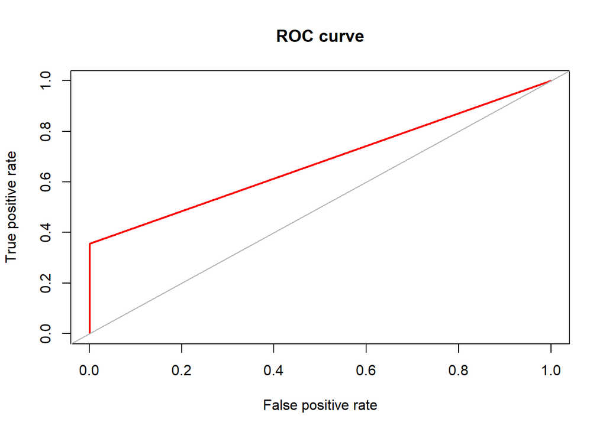

```
## Area under the curve (AUC): 0.678
```

```r
roc.curve(dados_teste_over$is_attributed, previsao6, plotit = T, col = "red")
```

#### 7.2.2 - Utilizando o C50:

Criando o modelo:

```r
modelo7 <- C5.0(data = dados_treino_over,
                        is_attributed ~ .)
```

Previsão:

```r
previsao7 <- predict(modelo7, dados_teste_over, type = 'class')
```

Criando uma confusion matrix:

```r
caret::confusionMatrix(previsao7, dados_teste_over$is_attributed,
                       positive = '1')
```

```
## Confusion Matrix and Statistics
##
##           Reference
## Prediction     0     1
##          0 29721 11879
##          1   211 18094
##
##                Accuracy : 0.7982
##                  95% CI : (0.7949, 0.8014)
##     No Information Rate : 0.5003
##     P-Value [Acc > NIR] : < 2.2e-16
##
##                   Kappa : 0.5965
##
##  Mcnemar's Test P-Value : < 2.2e-16
##
##             Sensitivity : 0.6037
##             Specificity : 0.9930
##          Pos Pred Value : 0.9885
##          Neg Pred Value : 0.7144
##              Prevalence : 0.5003
##          Detection Rate : 0.3020
##    Detection Prevalence : 0.3056
##       Balanced Accuracy : 0.7983
##
##        'Positive' Class : 1
##
```

Criando a Curva ROC para encontrar a métrica AUC:

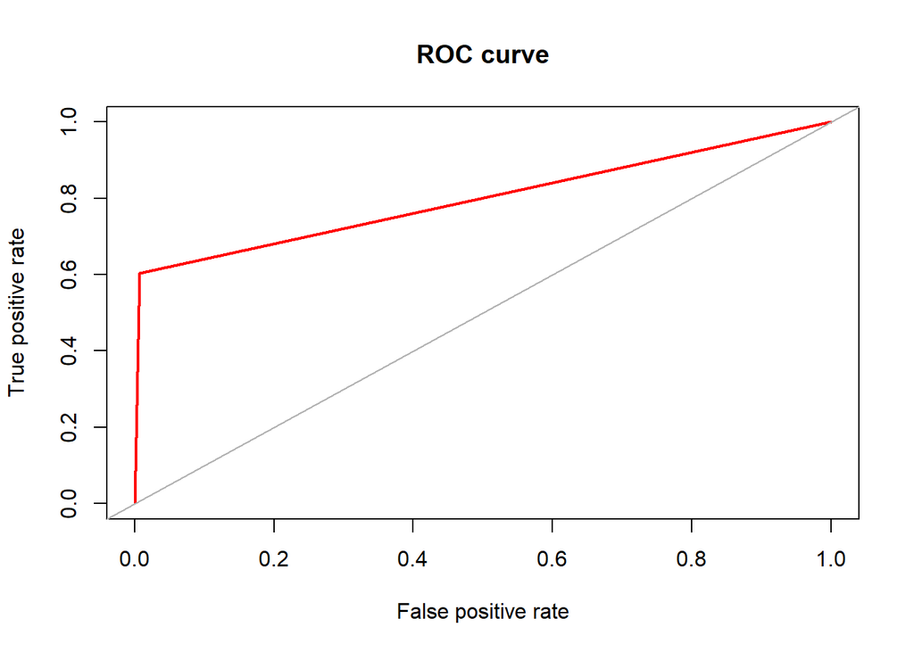

```
## Area under the curve (AUC): 0.798
```

```r
roc.curve(dados_teste_over$is_attributed, previsao7, plotit = T, col = "red")
```

#### **Acurácia** = 0.7982

#### **Score AUC** = 0.798

#### 7.2.3 - Utilizando o NaiveBayes:

Criando o modelo:

```r
modelo8 <- naiveBayes(data = dados_treino_over,
                is_attributed ~ .)
print(modelo8)
```

```
##
## Naive Bayes Classifier for Discrete Predictors
##
## Call:
## naiveBayes.default(x = X, y = Y, laplace = laplace)
##
## A-priori probabilities:
## Y
##         0         1
## 0.4998855 0.5001145
##
## Conditional probabilities:
##    ip
## Y        [,1]      [,2]
##   0  91042.23  69699.99
##   1 169972.68 106764.04
##
##    app
## Y       [,1]     [,2]
##   0 11.90382 14.31477
##   1 32.65902 34.45431
##
##    device
## Y       [,1]     [,2]
##   0 21.67415 259.7464
##   1 20.34720 102.2636
##
##    os
## Y       [,1]     [,2]
##   0 22.82911 56.01890
##   1 29.29305 89.70463
##
##    channel
## Y       [,1]     [,2]
##   0 268.9069 129.8621
##   1 208.6902 114.7512
##
##    click_time
## Y         [,1]     [,2]
##   0 1510122826 73892.31
##   1 1510119454 73994.29
```

Previsão:

```r
previsao8 <- predict(modelo8, dados_teste_over, type = 'class')
```

Criando uma confusion matrix:

```r
caret::confusionMatrix(previsao8, dados_teste_over$is_attributed,
                       positive = '1')
```

```
## Confusion Matrix and Statistics
##
##           Reference
## Prediction     0     1
##          0 26194  9676
##          1  3738 20297
##
##                Accuracy : 0.7761
##                  95% CI : (0.7727, 0.7794)
##     No Information Rate : 0.5003
##     P-Value [Acc > NIR] : < 2.2e-16
##
##                   Kappa : 0.5522
##
##  Mcnemar's Test P-Value : < 2.2e-16
##
##             Sensitivity : 0.6772
##             Specificity : 0.8751
##          Pos Pred Value : 0.8445
##          Neg Pred Value : 0.7302
##              Prevalence : 0.5003
##          Detection Rate : 0.3388
##    Detection Prevalence : 0.4012
##       Balanced Accuracy : 0.7761
##
##        'Positive' Class : 1
##
```

Criando a Curva ROC para encontrar a métrica AUC:

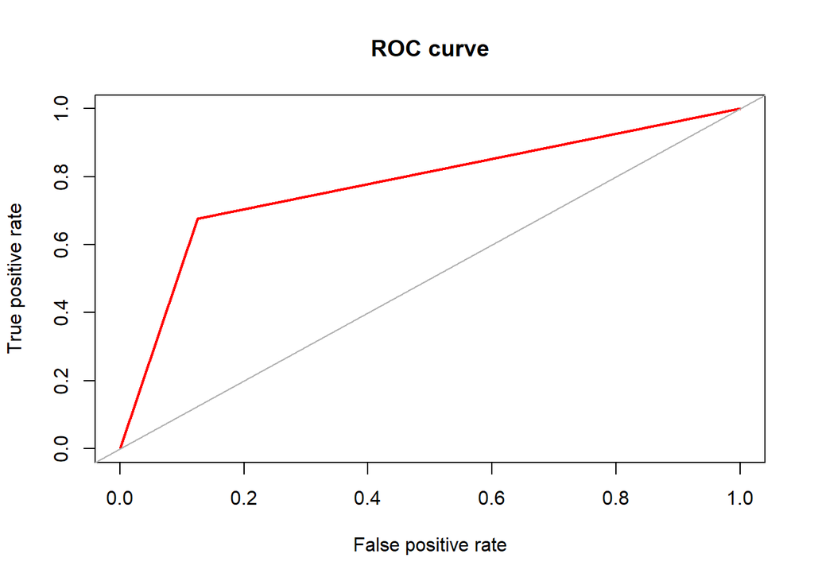

```
## Area under the curve (AUC): 0.776
```

```r
roc.curve(dados_teste_over$is_attributed, previsao8, plotit = T, col = "red")
```

#### **Acurácia** = 0.7761

#### **Score AUC** = 0.776

## **Conclusão:**

### O melhor resultado foi utilizando o algoritmo RPART com os dados balanceados pelo algoritmo ROSE, utilizando o método de Over Sampling. Nessas condições, foi obtido uma acurácia de 93,19% e um Score AUC de 93,20%.